# Brazilian Polling Station Data Quality Report

Automated Sanity Checks for 2024 Data Integration

Author

Pipeline Automated Report

Published

June 12, 2025

## Executive Summary

**Note**

**Report Generated**: 2025-06-12 06:41:23

**Data Coverage**: - Years: 2006 - 2024 - States: AC, RR - Total Polling Stations: 10,006 - Total Records: 10,006

### ✅ All Quality Checks Passed

## Data Preprocessing Notes

### Brasília (DF) Filtering

The Federal District (Brasília) has a special electoral status: - **No municipal elections**: As a Federal District, Brasília does not hold mayoral or city council elections - **Federal/State elections only**: Participates only in presidential, gubernatorial, senatorial, and legislative elections (every 4 years)

**Filtering Applied**: - Brasília polling stations have been removed from municipal election years (2008, 2012, 2016, 2020, 2024) - This filtering ensures accurate municipality counts and prevents false anomalies in year-over-year comparisons

```
No Brasília data found in the dataset.
```

```
✅ Brasília filtering verified: No records found in municipal election years.
```

## 1. Year-over-Year Polling Station Changes

### National Trends

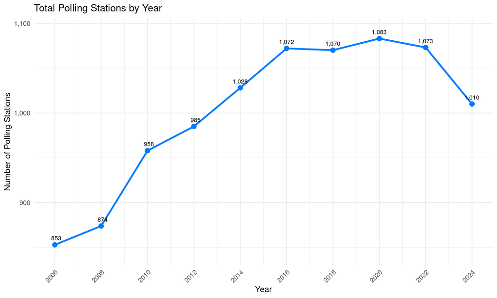

Number of polling stations over time

| Year | Polling Stations | Change | % Change |
| --- | --- | --- | --- |
| 2006 | 853 | -- | -- |
| 2008 | 874 | + 21 | +2.46% |
| 2010 | 958 | + 84 | +9.61% |
| 2012 | 985 | + 27 | +2.82% |
| 2014 | 1,028 | + 43 | +4.37% |
| 2016 | 1,072 | + 44 | +4.28% |
| 2018 | 1,070 | -2 | -0.19% |
| 2020 | 1,083 | + 13 | +1.21% |
| 2022 | 1,073 | -10 | -0.92% |
| 2024 | 1,010 | -63 | -5.87% |

### State-Level Analysis

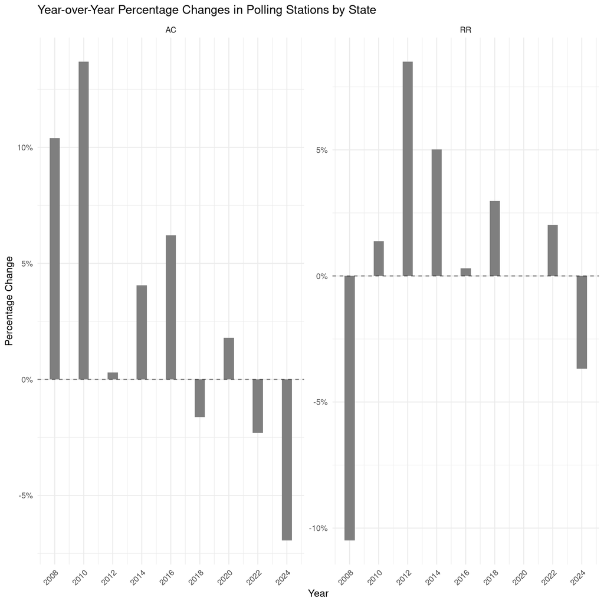

Year-over-year percentage changes by state

## 2. Municipality-Level Analysis

**Note**

**Note on Municipality Counts**: - Brazil has approximately 5,570 municipalities - Brasília (DF) is counted as a municipality but only appears in federal/state election years - New municipalities may be created through administrative divisions (e.g., Mojuí dos Campos in 2010) - The total count may vary by year due to these administrative changes

### Municipalities Overview

| Metric | Value |
| --- | --- |
| Total Municipalities | 37 |
| Average Stations per Municipality | 270.4 |
| Municipalities with 100% Geocoding | 37 |
| Municipalities Present All Years | 37 |

### Extreme Municipality Changes

The following table shows municipalities that experienced extreme changes (more than 30% increase or decrease) in the number of polling stations between 2022 and 2024. These cases may warrant further investigation.

| Municipality | State | 2022 Stations | 2024 Stations | Change | % Change |
| --- | --- | --- | --- | --- | --- |
| CAPIXABA | AC | 19 | 10 | -9 | -47.4% |

## 3. Panel ID Quality Analysis

### Panel Coverage Statistics

| Metric | Value |
| --- | --- |
| Total Unique Panels | 1,157 |
| Stations with Panel IDs | 9,946 |
| Panel Coverage Rate | 99.4% |
| Complete Panels (all years) | 710 |
| High Quality Panels (≥75% years) | 896 |
| Panels Spanning Multiple States | 0 |

### Panel Longevity Distribution

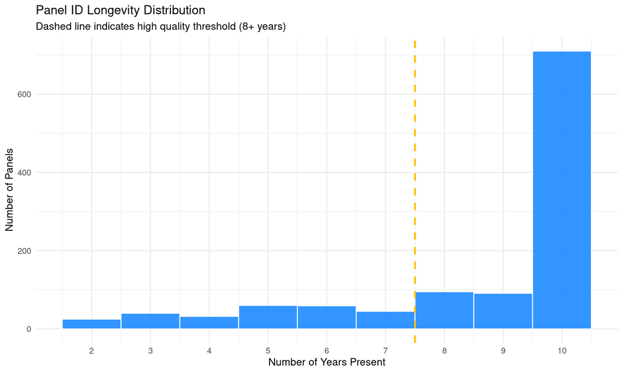

Distribution of panel longevity (years present in data)

| Quality | Count | Percentage |
| --- | --- | --- |
| Complete | 710 | 61.4% |
| High | 186 | 16.1% |
| Medium | 164 | 14.2% |
| Low | 97 | 8.4% |

## 4. Geocoding Coverage Analysis

### Geocoding Coverage by Year

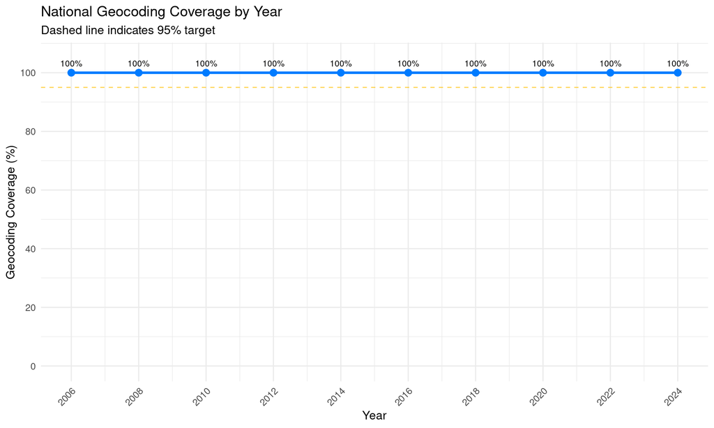

Geocoding coverage rate over time

### State-Level Geocoding Heatmap

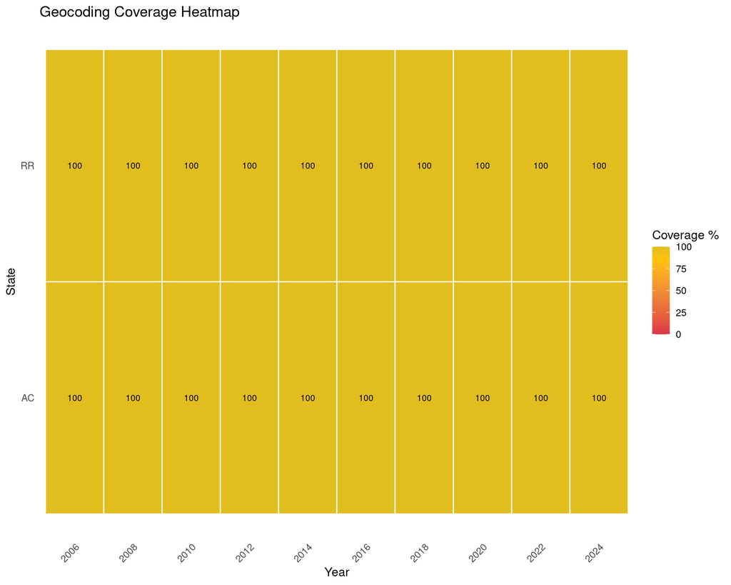

Geocoding coverage by state and year

## 5. Coordinate Duplicate Analysis

### Overview

This section analyzes cases where multiple polling stations share the exact same coordinates within the same election year.

**Note**

**Key Finding**: Analysis shows that **51.7%** of coordinate duplicates share the same address, confirming these are legitimate co-locations in large venues hosting multiple voting sections. Additionally, **94.9%** of duplicate locations have all stations in the same electoral zone.

### Coordinate Duplicate Statistics

| Metric | Value |
| --- | --- |
| Total duplicate locations | 661 |
| Total stations at duplicate coordinates | 1,616 |
| Locations with SAME address (expected) | 666 |
| Locations with DIFFERENT addresses (concerning) | 621 |
| % sharing same address | 51.7% |
| % sharing same electoral zone | 94.9% |

### Distribution by Year

| ano | duplicate_locations | total_stations | avg_stations_per_location | max_stations |
| --- | --- | --- | --- | --- |
| 2006 | 108 | 270 | 2.5 | 6 |
| 2008 | 88 | 230 | 2.61 | 8 |
| 2010 | 95 | 240 | 2.53 | 8 |
| 2012 | 88 | 211 | 2.4 | 5 |
| 2014 | 81 | 203 | 2.51 | 8 |
| 2016 | 86 | 202 | 2.35 | 5 |
| 2018 | 17 | 38 | 2.24 | 3 |
| 2020 | 20 | 47 | 2.35 | 3 |
| 2022 | 20 | 47 | 2.35 | 4 |
| 2024 | 58 | 128 | 2.21 | 5 |

### Concerning Cases: Different Addresses at Same Coordinates

The following table shows a sample of locations where multiple stations share coordinates but have **different addresses**. These cases may indicate geocoding errors and warrant investigation.

| Year | State | Municipality | # Stations | # Addresses | Address Examples | Station Names |
| --- | --- | --- | --- | --- | --- | --- |
| 2014 | AC | RIO BRANCO | 7 | 5 | RUA QUINTINO BOCAIUVA N 299 \| RUA RUI BARBOSA 410 \| RUA RIO GRANDE DO SUL 109 | OCA RIO BRANCO \| CAIXA AUXILIADORA DA GUARDA TERRITORIAL \| SERVICO DE APOIO A MI |
| 2010 | AC | RIO BRANCO | 6 | 5 | RUA MARECHAL DEODORO 243 \| RUA MARECHAL DEODORO 691 \| RUA MARECHAL DEODORO, 243 | SERVICO DE AGUA E ESGOTO DE RIO BRANCO-SAERB \| CENTRO DE CAPACITACAO DO SERV. DO |
| 2006 | AC | RIO BRANCO | 5 | 4 | RUA MARECHAL DEODORO 340 \| RUA MARECHAL DEODORO 691 \| RUA MARECHAL DEODORO 243 | MINISTERIO DA FAZENDA(RECEITA FEDERAL) \| CENTRO DE CAPACITACAO DO SERV. DO PODER |
| 2006 | AC | BRASILEIA | 5 | 4 | RUA GENY ASSIS \| RUA GENY ASSIS S/N S/N \| RUA GENY ASSIS S/N | CAMARA MUNICIPAL \| COLETORIA ESTADUAL \| IBAMA |
| 2010 | AC | RIO BRANCO | 5 | 5 | AVENIDA NACOES UNIDAS, 2.604 \| AVENIDA NACOES UNIDAS, 2.731 \| AVENIDA NACOES UNIDAS, 2.710 | SEAPROF \| FUMBESA - FUNDACAO DO BEM-ESTAR SOCIAL DO ACRE \| DETRAN-AC |
| 2012 | AC | RIO BRANCO | 5 | 5 | AVENIDA NACOES UNIDAS, 2.604 \| AVENIDA NACOES UNIDAS, 2.731 \| AVENIDA NACOES UNIDAS, 2.710 | SEAPROF \| FUMBESA - FUNDACAO DO BEM-ESTAR SOCIAL DO ACRE \| DETRAN-AC |
| 2006 | AC | TARAUACA | 4 | 4 | RUA CEL JUVENCIO MENEZES S/N \| CEL. JUVENCIO DE MENEZES, S/N \| CEL JUVENCIO DE MENEZES | CAMARA MUNICIPAL \| SECRETARIA MUNICIPAL DE EDUCACAO E CULTURA - SEMEC \| INSPETOR |
| 2010 | AC | TARAUACA | 4 | 3 | RUA CEL. JUVENCIO DE MENEZES, S/N \| CEL. JUVENCIO DE MENEZES, S/N \| CEL. JUVENCIO DE MENEZES, N. 301 | CAMARA MUNICIPAL \| SECRETARIA MUNICIPAL DE EDUCACAO E CULTURA - SEMEC \| INSPETOR |
| 2016 | AC | RIO BRANCO | 4 | 4 | ESTRADA DO AVIARIO, 233 \| RUA DO AVIARIO 315 \| ESTRADA DO AVIARIO, 23 | ESCOLA CASTELO BRANCO \| DEPARTAMENTO DE PRODUCAO ANIMAL DA SECRETARIA DES. AGRAR |
| 2016 | AC | SENA MADUREIRA | 4 | 4 | AV. AVELINO CHAVES \| AV. AVELINO CHAVES, S/N \| AV AVELINO CHAVES, S/N | EEEFISJ - ESCOLA ESTADUAL ENSINO FUNDAMENTAL INSTITUTO SANTA JULIANA \| EEFMET - |

[output cut: 90 more lines]

### Expected Cases: Same Address Examples

For comparison, here are examples where stations share coordinates AND addresses (expected behavior):

Examples of expected coordinate sharing (same address)

| Year | State | Municipality | # Stations | Shared Address | Station Names |
| --- | --- | --- | --- | --- | --- |
| 2020 | AC | SENADOR GUIOMARD | 1 | RUA 03 DE MAIO DOS EDIS 569 | CAMARA MUNICIPAL |
| 2008 | AC | RIO BRANCO | 1 | RUA 16 DE OUTUBRO 165 | INSTITUTO IMACULADA CONCEICAO - CENEC |
| 2014 | AC | RIO BRANCO | 1 | AVENIDA EPAMINONDAS JACOME 643 | ANTIGO COLEGIO META I |
| 2014 | AC | RIO BRANCO | 1 | CONJUNTO TUCUMA II | ESCOLA PUBLICA RAIMUNDO GOMES DE OLIVEIRA |
| 2016 | RR | MUCAJAI | 1 | AVENIDA MARANHAO | PADRE JOSE MONTICONE |
| 2012 | AC | XAPURI | 2 | RUA CORONEL BRANDAO | CLUBE MUNICIPAL - ASSEMUX \| NUCLEO DA UFAC |
| 2020 | AC | CAPIXABA | 1 | BR 317 KM 100, RAMAL LIMEIRA KM 07 | ESCOLA MUNICIPAL LIMEIRA |
| 2008 | AC | RIO BRANCO | 1 | RUA 24 DE JANEIRO 269 | CENTRO RECREATIVO TENTAMEN |
| 2006 | RR | IRACEMA | 1 | AVENIDA BERNARDO SAIAO, S/N | IRACEMA AGUIAR PEREIRA E.E. |
| 2016 | AC | CRUZEIRO DO SUL | 1 | AV. 15 DE NOVEMBRO | SECRETARIA MUNICIPAL DO MEIO AMBIENTE |

## 6. Data Quality Summary

### Quality Metrics Dashboard

| Metric | Value | Threshold | Status |
| --- | --- | --- | --- |
| Panel ID Coverage | 99.4% | 90% | Pass |
| Geocoding Coverage | 100% | 95% | Pass |
| Maximum YoY Change | 9.6% | 15% | Pass |
| Years Coverage | 10 of 10 | 10 | Pass |

### Final Assessment

**✅ All Quality Checks Passed**

The polling station data meets all quality thresholds. The data integration appears successful with high quality metrics across all dimensions.

Report generated by the Brazilian Polling Station Geocoding Pipeline  
R version 4.5.0 (2025-04-11)